# HydroGym #2

Getting Started Examples

# Contents

- Setup
  - 0. Getting Started
- Basic Structure
  - 1. Example 1: Basic Cylinder Environment
  - 2. Example 2: Simulation with Multiple Substeps
  - 3. Example 3: Training with Stable-Baselines3
- Checkpoints
  - 4. Example 5: Local Checkpoint Directory
  - 5. Example 4: Automatic Checkpoint Loading
  - 6. Example 6: Multiple Checkpoints for Curriculum Learning
- Development
  - 7. Example 7: Probe-Based Observation
  - 8. Example 8: Using Callbacks

## 0. Getting Started

The README at `examples/firedrake/getting_started/README.md` in the Dynamics Lab GitHub repository

introduces `config_reference.py`, `test_firedrake.py`, and `train_sb3_firedrake.py`.

`config_reference.py` contains improved versions of the example code provided on the website.

`test_firedrake.py` tests the environment.

`train_sb3_firedrake.py` provides an example of training an RL agent.

### Errors When Running the Example

The official tutorial provides the following commands:

```bash
# Single process
python test_firedrake_env.py --environment cylinder --num-steps 10

# MPI parallel
mpirun -np 4 python test_firedrake_env.py --environment cylinder --num-steps 50
```

When running the official HydroGym Firedrake example, the environment failed before the CFD simulation started.

```
File is not a valid Gmsh file,
expecting $MeshFormat, not version
```

The error occurred while Firedrake was loading the `medium.msh` file.

### Root Cause: Git LFS Pointer File

The installed `medium.msh` was inspected:

```bash
head -n 3 medium.msh
```

Output:

```
version https://git-lfs.github.com/spec/v1
oid sha256: ...
size ...
```

- The file was **not an actual Gmsh mesh**.
- It was only a **Git LFS pointer file**.
- Therefore, Firedrake could not recognize it as a valid mesh.

### Solution

The mesh was regenerated from the provided `.geo` file:

```bash
gmsh medium.geo -2 -format msh2 -o medium.msh
```

The regenerated file had the correct Gmsh format:

```
$MeshFormat
2.2 0 8
$EndMeshFormat
```

After regeneration:

- Firedrake successfully loaded the mesh.
- HydroGym correctly recognized the environment.
- The simulation proceeded to checkpoint loading.

**Key lesson:** Verify the actual mesh file before debugging the CFD solver.

## 1. Example 1: Basic Cylinder Environment

- This example shows the basic code structure.
- The key configuration is:

```python
env_config = {
    'flow': hgym.Cylinder,
    'flow_config': {'mesh': 'medium', 'Re': 100},
    'solver': hgym.SemiImplicitBDF,
    'solver_config': {'dt': 1e-2},
}
```

[video not shown]

Ex.1

## 2. Example 2: Simulation with Multiple Substeps

- The action is not updated at every solver step.
- One action is applied over n solver steps.
- This saves computational resources and improves performance.

```python
env_config = {
    'flow': hgym.Cylinder,
    'flow_config': {'mesh': 'medium', 'Re': 100},
    'solver': hgym.SemiImplicitBDF,
    'solver_config': {'dt': 1e-2},
    'actuation_config': {
        'num_substeps': 5,              # Run 5 solver steps per action
        'reward_aggregation': 'mean',   # Average rewards over substeps
    },
}
```

## 3. Example 3: Training with Stable-Baselines3

- Stable-Baselines3 is a Python library that provides standard RL algorithms.
- In particular, it provides PPO, DDPG, and TD3.

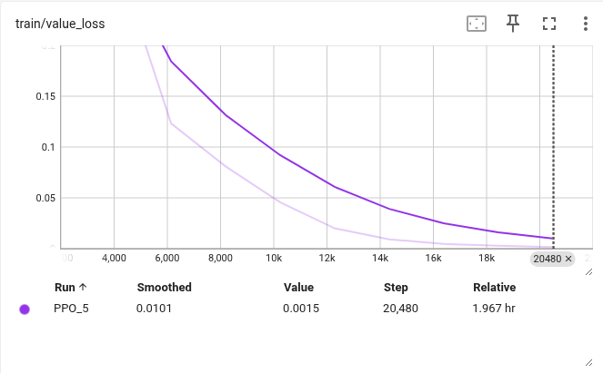

Loss

## 4. Example 5: Local Checkpoint Directory

- A checkpoint is a saved state during training.
- Users can resume from a checkpoint.
- Dynamics Lab provides many checkpoints on Hugging Face.
- The checkpoint files have the `.ckpt` extension.
- The official example code uses `.h5` checkpoint files.
- I confirmed that `.ckpt` files also work.
- I used the `Cavity_2D_Re7500_medium_FD` checkpoint from Dynamics Lab.
- Unfortunately, the dataset is large, so I downloaded only a small portion.
- This may cover approximately 0–0.025 s.

[Link](https://huggingface.co/datasets/dynamicslab/HydroGym-environments/tree/main/Cavity_2D_Re7500_medium_FD)

[video not shown]

## 5. Example 4: Automatic Checkpoint Loading

- I am not sure what the author means.
- Does this mean that HydroGym automatically finds a checkpoint on Hugging Face?
- Or does it find a checkpoint already included with the HydroGym examples?

```python
# Checkpoints are automatically inferred from flow config and downloaded from HF Hub
env_config = {
    'flow': hgym.Cylinder,
    'flow_config': {
        'mesh': 'medium',
        'Re': 100,
        # No 'restart' specified - automatically loads 'Cylinder_2D_Re100_medium_FD'
    },
    'solver': hgym.SemiImplicitBDF,
    'solver_config': {'dt': 1e-2},
}

env = FlowEnv(env_config)
# Checkpoint auto-downloaded from HF Hub and loaded!
print(f"Loaded checkpoint: {env.flow.checkpoint_path}")
```

## 6. Example 6: Multiple Checkpoints for Curriculum Learning

- I specify several initial states.
- The RL agent randomly selects an initial state from those I specified.
- This increases the diversity of training states and helps the policy generalize beyond a single initial condition.

```python
env_config = {
    'flow': hgym.Pinball,
    'flow_config': {
        'mesh': 'fine',
        'Re': 30,
        'restart': [
            'checkpoint_early.h5',
            'checkpoint_mid.h5',
            'checkpoint_late.h5',
        ],
    },
    'solver': hgym.SemiImplicitBDF,
    'solver_config': {'dt': 1e-2},
}
```

## 7. Example 7: Probe-Based Observation

- Specify probe locations that we consider important.
- Use observations from these probes for training.

```python
import numpy as np

# Define wake probes
wake_probes = [(x, 0.0) for x in np.linspace(1.0, 10.0, 20)]

env_config = {
    'flow': hgym.Cylinder,
    'flow_config': {
        'mesh': 'medium',
        'Re': 100,
        'observation_type': 'velocity_probes',
        'probes': wake_probes,
    },
    'solver': hgym.SemiImplicitBDF,
    'solver_config': {'dt': 1e-2},
}

env = FlowEnv(env_config)
obs, _ = env.reset()
print(f"Observation shape: {obs.shape}")  # (40,) for 20 probes × 2 velocity components
```

- Probe output

```
Observation shape: (40,)
obs[-0.15488237 -0.16019162 -0.06361766  0.09369587  0.42523721  0.66388656
  0.71783966  0.64501864  0.6285661   0.76957667  0.85741427  0.85094709
  0.79187414  0.72624329  0.74207829  0.82027832  0.86069161  0.84759284
  0.79587634  0.75231327 -0.17196294  0.18677793  0.57868901  0.50837954
 -0.08409665 -0.54991825 -0.57680305 -0.54979187 -0.25181187  0.33382708
  0.52058526  0.4909093   0.49293956  0.30499254 -0.18298415 -0.43957614
 -0.43968621 -0.4333516  -0.38675252 -0.07394321]
```

## 8. Example 8: Using Callbacks

- A callback is a function or object called automatically at specified points during execution.
- It can perform tasks such as logging or saving checkpoints.

```python
from hydrogym.firedrake.io import CheckpointCallback, LogCallback
```

### Error in My Environment

- The import failed in my installed HydroGym environment.

```
ModuleNotFoundError: No module named 'hydrogym.firedrake.io'
```

- Therefore, I could not run the callback example.
- Basic simulations can still run without these callbacks.